# HIV Splicing Assay Report (Test Report for Main Functions in qmd)

Author

Shuntai Zhou and Michael Clark @UNC-CH

✦ ✦ ✦

## 1 Run settings

**Important**

**Assay type:** RANDOM-REVERSE

**Reference type:** NL43

**Mismatch allowed:** 1

**Input File 1 path:** nl43_r1.fastq.gz

**Input File 2 path:** nl43_r2.fastq.gz

**Note**

**Output Files:**

1. *TSV file:* Splice isoform analysis for each sequence, one record per sequence. NOTE: sequences with low qualities are removed.
2. *CSF file:* Summarized splice isoform analysis. One record per UMI family. NOTE: UMI family size less than 3 are not shown.
3. *HTML file:* Splice isoform analysis and visualization.

✦ ✦ ✦

## 2 Overal Spliced vs. Unpliced

### 2.1 Summary table

|  | Overall (N=31980) |
| --- | --- |
| **spliced** |  |
| spliced | 8570 (26.8%) |
| unspliced | 23122 (72.3%) |
| unknown | 288 (0.9%) |

### 2.2 Percent spliced

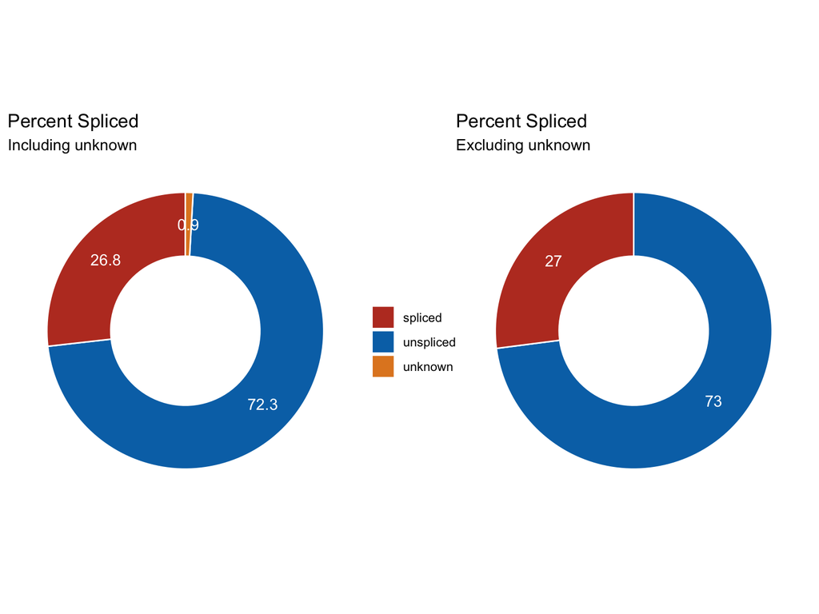

**Caution**

Unknown splice types can come from mismatches (sequencing errors), unrecognized patterns or non-HIV sequences. If greater than 5%, please check the raw TSV file for details.

✦ ✦ ✦

## 3 D1 types

D1 Type of splice isoforms

|  | Overall (N=8570) |
| --- | --- |
| **D1 types** |  |
| Alternative D1 | 5 (0.1%) |
| D1 | 8565 (99.9%) |

D1 Type of splice isoforms (detailed types)

|  | Overall (N=8570) |
| --- | --- |
| **Detailed D1 types** |  |
| GC 3 base downstream of DIS | 1 (0.0%) |
| GC 10 base downstream of DIS | 0 (0.0%) |
| D1 | 8565 (99.9%) |
| D1prime | 0 (0.0%) |
| GU downstream gag AUG | 0 (0.0%) |
| GU further downstream in gag | 0 (0.0%) |
| Others | 4 (0.0%) |

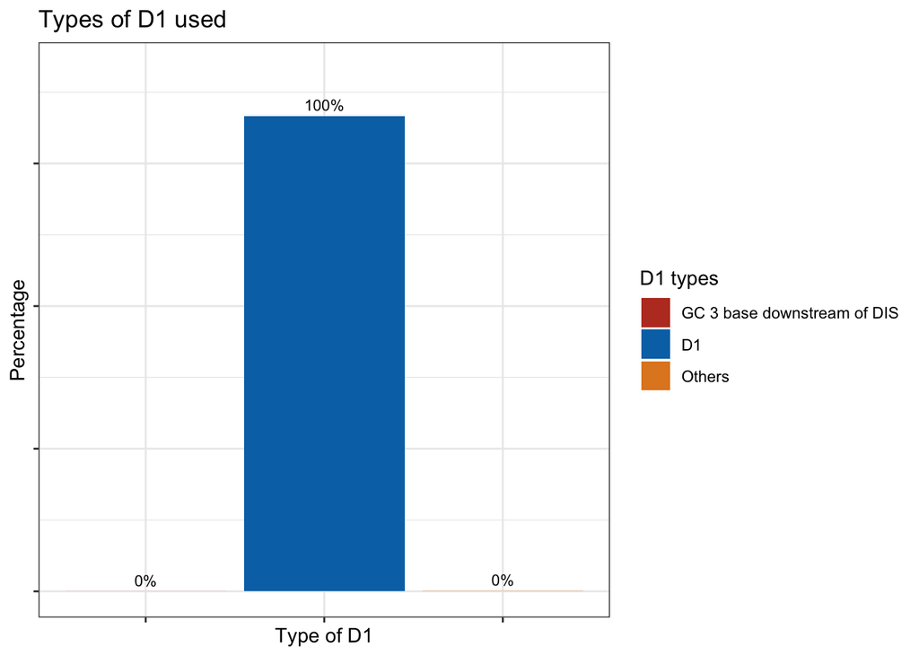

**Caution**

**Source of “Others” in D1 types:**

- Mismatched alternative D1
- Mismatched upstream acceptor sequences
- Potential PCR bias (PCR primer matching acceptor sequences)
- Other alternative D1 sites.

**If substantial amount of “Other D1” is observed, refer to TSV file for details.**

✦ ✦ ✦

## 4 Splice Isoforms

### 4.1 Splice Isoforms by Major D1 types

Splice isoforms by major D1 types

|  | Alternative D1 (N=5) | D1 (N=8565) | Total (N=8570) | p value |
| --- | --- | --- | --- | --- |
| **Splice isoforms (Shortened)** |  |  |  | 0.990 |
| D1_A1_D2_A2_D3_A3 | 1 (20.0%) | 173 (2.0%) | 174 (2.0%) |  |
| D1_A1_D2_A2_D3_A4 | 0 (0.0%) | 194 (2.3%) | 194 (2.3%) |  |
| D1_A1_D2_A2_D3_A5 | 0 (0.0%) | 315 (3.7%) | 315 (3.7%) |  |
| D1_A1_D2_A2_D3_D3-unspliced | 0 (0.0%) | 69 (0.8%) | 69 (0.8%) |  |
| D1_A1_D2_A3 | 1 (20.0%) | 1409 (16.5%) | 1410 (16.5%) |  |
| D1_A1_D2_A4 | 0 (0.0%) | 13 (0.2%) | 13 (0.2%) |  |
| D1_A1_D2_A5 | 0 (0.0%) | 117 (1.4%) | 117 (1.4%) |  |
| D1_A1_D2_D2-unspliced_D2b_A2_D3_A3 | 0 (0.0%) | 16 (0.2%) | 16 (0.2%) |  |
| D1_A1_D2_D2-unspliced_D2b_A2_D3_A4 | 0 (0.0%) | 28 (0.3%) | 28 (0.3%) |  |
| D1_A1_D2_D2-unspliced_D2b_A2_D3_A5 | 0 (0.0%) | 15 (0.2%) | 15 (0.2%) |  |
| D1_A1_D2_D2-unspliced_D2b_A2_D3_D3-unspliced | 0 (0.0%) | 4 (0.0%) | 4 (0.0%) |  |
| D1_A1_D2_D2-unspliced_D2b_A3 | 0 (0.0%) | 107 (1.2%) | 107 (1.2%) |  |
| D1_A1_D2_D2-unspliced_D2b_A4 | 0 (0.0%) | 11 (0.1%) | 11 (0.1%) |  |
| D1_A1_D2_D2-unspliced_D2b_A5 | 0 (0.0%) | 5 (0.1%) | 5 (0.1%) |  |
| D1_A1_D2_D2-unspliced_D2b_D2b-unspliced | 0 (0.0%) | 84 (1.0%) | 84 (1.0%) |  |
| D1_A2_D3_A3 | 0 (0.0%) | 425 (5.0%) | 425 (5.0%) |  |
| D1_A2_D3_A4 | 0 (0.0%) | 23 (0.3%) | 23 (0.3%) |  |
| D1_A2_D3_A5 | 0 (0.0%) | 87 (1.0%) | 87 (1.0%) |  |
| D1_A2_D3_D3-unspliced | 1 (20.0%) | 1045 (12.2%) | 1046 (12.2%) |  |
| D1_A3 | 2 (40.0%) | 2721 (31.8%) | 2723 (31.8%) |  |
| D1_A4 | 0 (0.0%) | 236 (2.8%) | 236 (2.8%) |  |
| D1_A5 | 0 (0.0%) | 1164 (13.6%) | 1164 (13.6%) |  |
| D1_A7 | 0 (0.0%) | 22 (0.3%) | 22 (0.3%) |  |
| Incomplete | 0 (0.0%) | 282 (3.3%) | 282 (3.3%) |  |

### 4.2 Splice Isoforms by Detailed D1 types

Splice isoforms by detailed D1 types

|  | GC 3 base downstream of DIS (N=1) | D1 (N=8565) | Others (N=4) | Total (N=8570) | p value |
| --- | --- | --- | --- | --- | --- |
| **Splice isoforms (Shortened)** |  |  |  |  | 1.000 |
| D1_A1_D2_A2_D3_A3 | 0 (0.0%) | 173 (2.0%) | 1 (25.0%) | 174 (2.0%) |  |
| D1_A1_D2_A2_D3_A4 | 0 (0.0%) | 194 (2.3%) | 0 (0.0%) | 194 (2.3%) |  |
| D1_A1_D2_A2_D3_A5 | 0 (0.0%) | 315 (3.7%) | 0 (0.0%) | 315 (3.7%) |  |
| D1_A1_D2_A2_D3_D3-unspliced | 0 (0.0%) | 69 (0.8%) | 0 (0.0%) | 69 (0.8%) |  |
| D1_A1_D2_A3 | 0 (0.0%) | 1409 (16.5%) | 1 (25.0%) | 1410 (16.5%) |  |
| D1_A1_D2_A4 | 0 (0.0%) | 13 (0.2%) | 0 (0.0%) | 13 (0.2%) |  |
| D1_A1_D2_A5 | 0 (0.0%) | 117 (1.4%) | 0 (0.0%) | 117 (1.4%) |  |
| D1_A1_D2_D2-unspliced_D2b_A2_D3_A3 | 0 (0.0%) | 16 (0.2%) | 0 (0.0%) | 16 (0.2%) |  |
| D1_A1_D2_D2-unspliced_D2b_A2_D3_A4 | 0 (0.0%) | 28 (0.3%) | 0 (0.0%) | 28 (0.3%) |  |
| D1_A1_D2_D2-unspliced_D2b_A2_D3_A5 | 0 (0.0%) | 15 (0.2%) | 0 (0.0%) | 15 (0.2%) |  |
| D1_A1_D2_D2-unspliced_D2b_A2_D3_D3-unspliced | 0 (0.0%) | 4 (0.0%) | 0 (0.0%) | 4 (0.0%) |  |
| D1_A1_D2_D2-unspliced_D2b_A3 | 0 (0.0%) | 107 (1.2%) | 0 (0.0%) | 107 (1.2%) |  |
| D1_A1_D2_D2-unspliced_D2b_A4 | 0 (0.0%) | 11 (0.1%) | 0 (0.0%) | 11 (0.1%) |  |
| D1_A1_D2_D2-unspliced_D2b_A5 | 0 (0.0%) | 5 (0.1%) | 0 (0.0%) | 5 (0.1%) |  |
| D1_A1_D2_D2-unspliced_D2b_D2b-unspliced | 0 (0.0%) | 84 (1.0%) | 0 (0.0%) | 84 (1.0%) |  |
| D1_A2_D3_A3 | 0 (0.0%) | 425 (5.0%) | 0 (0.0%) | 425 (5.0%) |  |
| D1_A2_D3_A4 | 0 (0.0%) | 23 (0.3%) | 0 (0.0%) | 23 (0.3%) |  |
| D1_A2_D3_A5 | 0 (0.0%) | 87 (1.0%) | 0 (0.0%) | 87 (1.0%) |  |
| D1_A2_D3_D3-unspliced | 0 (0.0%) | 1045 (12.2%) | 1 (25.0%) | 1046 (12.2%) |  |
| D1_A3 | 1 (100.0%) | 2721 (31.8%) | 1 (25.0%) | 2723 (31.8%) |  |
| D1_A4 | 0 (0.0%) | 236 (2.8%) | 0 (0.0%) | 236 (2.8%) |  |
| D1_A5 | 0 (0.0%) | 1164 (13.6%) | 0 (0.0%) | 1164 (13.6%) |  |
| D1_A7 | 0 (0.0%) | 22 (0.3%) | 0 (0.0%) | 22 (0.3%) |  |
| Incomplete | 0 (0.0%) | 282 (3.3%) | 0 (0.0%) | 282 (3.3%) |  |

✦ ✦ ✦

## 5 Acceptors After D1

### 5.1 By Major D1 Types

Acceptor After D1 by major D1 types

|  | Alternative D1 (N=5) | D1 (N=8565) | Total (N=8570) | p value |
| --- | --- | --- | --- | --- |
| **Main Acceptor After D1** |  |  |  | 0.961 |
| A1 | 2 (40.0%) | 2840 (33.2%) | 2842 (33.2%) |  |
| A2 | 1 (20.0%) | 1582 (18.5%) | 1583 (18.5%) |  |
| A3 | 2 (40.0%) | 2721 (31.8%) | 2723 (31.8%) |  |
| A4 | 0 (0.0%) | 236 (2.8%) | 236 (2.8%) |  |
| A5 | 0 (0.0%) | 1164 (13.6%) | 1164 (13.6%) |  |
| A7 | 0 (0.0%) | 22 (0.3%) | 22 (0.3%) |  |

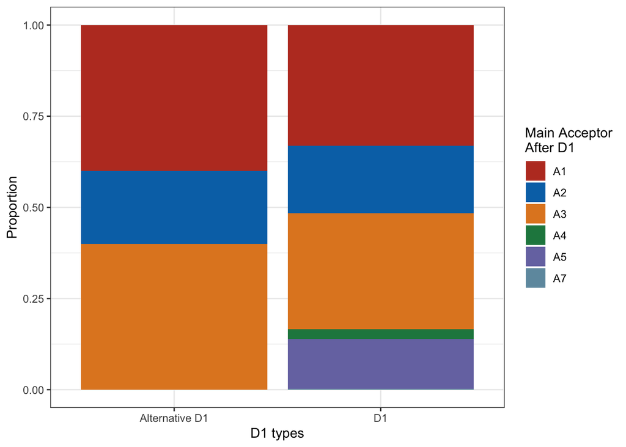

### 5.2 By Detailed D1 Types

Acceptor After D1 by detailed D1 types

|  | GC 3 base downstream of DIS (N=1) | D1 (N=8565) | Others (N=4) | Total (N=8570) | p value |
| --- | --- | --- | --- | --- | --- |
| **Main Acceptor After D1** |  |  |  |  | 0.973 |
| A1 | 0 (0.0%) | 2840 (33.2%) | 2 (50.0%) | 2842 (33.2%) |  |
| A2 | 0 (0.0%) | 1582 (18.5%) | 1 (25.0%) | 1583 (18.5%) |  |
| A3 | 1 (100.0%) | 2721 (31.8%) | 1 (25.0%) | 2723 (31.8%) |  |
| A4 | 0 (0.0%) | 236 (2.8%) | 0 (0.0%) | 236 (2.8%) |  |
| A5 | 0 (0.0%) | 1164 (13.6%) | 0 (0.0%) | 1164 (13.6%) |  |
| A7 | 0 (0.0%) | 22 (0.3%) | 0 (0.0%) | 22 (0.3%) |  |

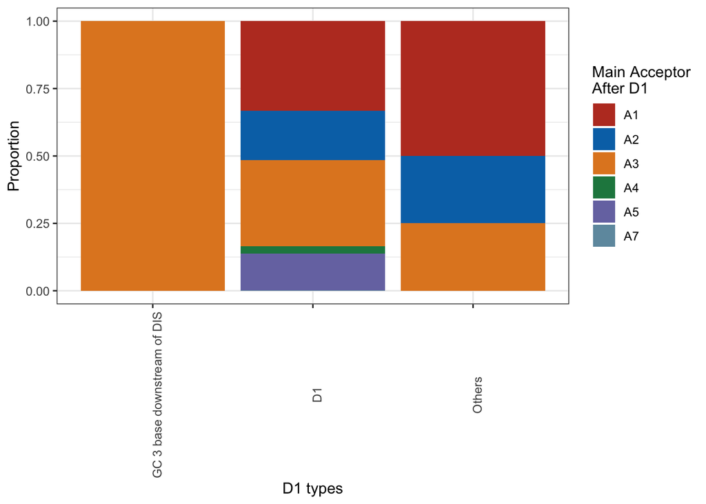

✦ ✦ ✦

## 6 Final Destination Summary

### 6.1 By Major D1 Types

Final desitinations by major D1 types

|  | Alternative D1 (N=5) | D1 (N=8565) | Total (N=8570) | p value |
| --- | --- | --- | --- | --- |
| **Final Destinations** |  |  |  | 0.902 |
| A3 | 4 (80.0%) | 4851 (56.6%) | 4855 (56.7%) |  |
| A4 | 0 (0.0%) | 505 (5.9%) | 505 (5.9%) |  |
| A5 | 0 (0.0%) | 1703 (19.9%) | 1703 (19.9%) |  |
| A7 | 0 (0.0%) | 22 (0.3%) | 22 (0.3%) |  |
| vif | 0 (0.0%) | 84 (1.0%) | 84 (1.0%) |  |
| vpr | 1 (20.0%) | 1118 (13.1%) | 1119 (13.1%) |  |
| Incomplete | 0 (0.0%) | 282 (3.3%) | 282 (3.3%) |  |

### 6.2 By Detailed D1 types

Final desitinations by detailed D1 types

|  | GC 3 base downstream of DIS (N=1) | D1 (N=8565) | Others (N=4) | Total (N=8570) | p value |
| --- | --- | --- | --- | --- | --- |
| **Final Destinations** |  |  |  |  | 0.998 |
| A3 | 1 (100.0%) | 4851 (56.6%) | 3 (75.0%) | 4855 (56.7%) |  |
| A4 | 0 (0.0%) | 505 (5.9%) | 0 (0.0%) | 505 (5.9%) |  |
| A5 | 0 (0.0%) | 1703 (19.9%) | 0 (0.0%) | 1703 (19.9%) |  |
| A7 | 0 (0.0%) | 22 (0.3%) | 0 (0.0%) | 22 (0.3%) |  |
| vif | 0 (0.0%) | 84 (1.0%) | 0 (0.0%) | 84 (1.0%) |  |
| vpr | 0 (0.0%) | 1118 (13.1%) | 1 (25.0%) | 1119 (13.1%) |  |
| Incomplete | 0 (0.0%) | 282 (3.3%) | 0 (0.0%) | 282 (3.3%) |  |

✦ ✦ ✦

## 7 Final Destinations by splice flows

**Note**

“Others” in D1 type are excluded in this analysis.

### 7.1 A3

|  | Overall (N=4852) |
| --- | --- |
| **Splice isoforms (Shortened)** |  |
| D1_A1_D2_A2_D3_A3 | 173 (3.6%) |
| D1_A1_D2_A3 | 1409 (29.0%) |
| D1_A1_D2_D2-unspliced_D2b_A2_D3_A3 | 16 (0.3%) |
| D1_A1_D2_D2-unspliced_D2b_A3 | 107 (2.2%) |
| D1_A2_D3_A3 | 425 (8.8%) |
| D1_A3 | 2722 (56.1%) |

### 7.2 A4

|  | Overall (N=505) |
| --- | --- |
| **Splice isoforms (Shortened)** |  |
| D1_A1_D2_A2_D3_A4 | 194 (38.4%) |
| D1_A1_D2_A4 | 13 (2.6%) |
| D1_A1_D2_D2-unspliced_D2b_A2_D3_A4 | 28 (5.5%) |
| D1_A1_D2_D2-unspliced_D2b_A4 | 11 (2.2%) |
| D1_A2_D3_A4 | 23 (4.6%) |
| D1_A4 | 236 (46.7%) |

### 7.3 A5

|  | Overall (N=1703) |
| --- | --- |
| **Splice isoforms (Shortened)** |  |
| D1_A1_D2_A2_D3_A5 | 315 (18.5%) |
| D1_A1_D2_A5 | 117 (6.9%) |
| D1_A1_D2_D2-unspliced_D2b_A2_D3_A5 | 15 (0.9%) |
| D1_A1_D2_D2-unspliced_D2b_A5 | 5 (0.3%) |
| D1_A2_D3_A5 | 87 (5.1%) |
| D1_A5 | 1164 (68.3%) |

### 7.4 A7

|  | Overall (N=22) |
| --- | --- |
| **Splice isoforms (Shortened)** |  |
| D1_A7 | 22 (100.0%) |

### 7.5 vif

|  | Overall (N=84) |
| --- | --- |
| **Splice isoforms (Shortened)** |  |
| D1_A1_D2_D2-unspliced_D2b_D2b-unspliced | 84 (100.0%) |

### 7.6 vpr

|  | Overall (N=1118) |
| --- | --- |
| **Splice isoforms (Shortened)** |  |
| D1_A1_D2_A2_D3_D3-unspliced | 69 (6.2%) |
| D1_A1_D2_D2-unspliced_D2b_A2_D3_D3-unspliced | 4 (0.4%) |
| D1_A2_D3_D3-unspliced | 1045 (93.5%) |

✦ ✦ ✦

## 8 Splicing Events Cascade Summary

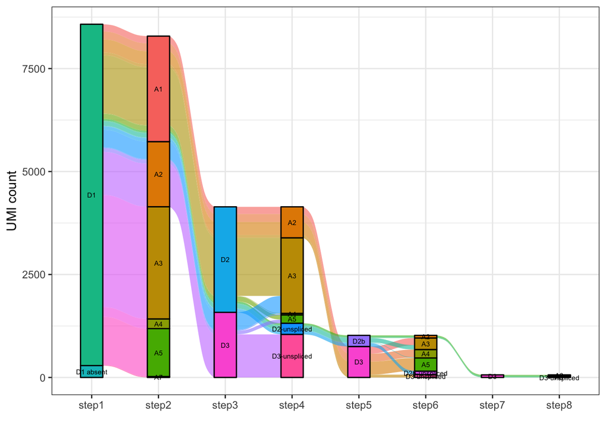

✦ ✦ ✦

## 9 Splice Cascade Analysis

### 9.1 Events after A1

Summarize the percent unspliced after A1 which is vif in the total reads that reach A1

|  | Overall (N=2842) |
| --- | --- |
| **Splice Events After A1** |  |
| Spliced at D2/D2b | 2635 (92.7%) |
| No splicing after A1/vif | 84 (3.0%) |
| Incomplete | 16 (0.6%) |
| Sequence after D2/D2b unrecognized | 107 (3.8%) |

**Tip**

The category *“Sequence after D2/D2b unrecognized”* comes from:

1. mismatches due to sequencing error/quality drop.
2. other patterns.
3. short sequences.

### 9.2 Events after A2

**Splice outcomes at A2 by Upstream Acceptor**

|  | D1->A1->A2 (N=972) | D1->A2 (N=1583) | Total (N=2555) | p value |
| --- | --- | --- | --- | --- |
| **Splice Events After A2** |  |  |  | < 0.001 |
| Spliced at D3 | 742 (76.3%) | 535 (33.8%) | 1277 (50.0%) |  |
| No splicing after A2/vpr | 73 (7.5%) | 1046 (66.1%) | 1119 (43.8%) |  |
| Incomplete | 48 (4.9%) | 0 (0.0%) | 48 (1.9%) |  |
| Sequence after D3 too short/unrecognized | 109 (11.2%) | 2 (0.1%) | 111 (4.3%) |  |

**Tip**

The category *“Sequence after D3 too short/unrecognized”* comes from:

1. mismatches due to sequencing error/quality drop.
2. short sequences, often in Random-Reverse assay.

It is possible the *Incomplete* group can also come from short reads in Random-Reverse assay.

✦ ✦ ✦